# 🚀 Advanced Exploratory Data Analysis EDA — High-Integrity Systems

This notebook focuses on developing deeper insights into high-integrity system data through EDA tasks. You’ll investigate patterns, anomalies, and correlations across system metrics using Python.

This version includes:

- Conceptual understanding
- Thought-provoking analysis
- Hands-on statistical interpretation

```python
import pandas as pd
import numpy as np
import matplotlib.pyplot as plt
from scipy.stats import skew, kurtosis

import seaborn as sns
sns.set(style='whitegrid')
```

#### Load the data

```python
df = pd.read_csv("generated_his_system_metrics.csv", index_col=0)
df.head()
```

| system_id | sensor_latency_ms | cpu_usage_percent | memory_usage_mb | error_count | uptime_hours | mode | temperature_sensor | CPU_temperature | CPU_thermostat_stability | sensor_thermostat_stability |
| --- | --- | --- | --- | --- | --- | --- | --- | --- | --- | --- |
| 1 | 22.483571 | 58.892663 | 420.457194 | 0 | 130.837373 | normal | 26.146247 | 50.9 | 956.574776 | 111.788151 |
| 2 | 19.308678 | 73.641250 | 316.802495 | 0 | 48.285983 | normal | 56.447908 | 59.1 | 1039.893818 | 87.168360 |
| 3 | 23.238443 | 24.021486 | 174.484049 | 1 | 92.523906 | normal | 57.172326 | 48.8 | 1011.319140 | 83.611087 |
| 4 | 27.615149 | 53.444539 | 96.321615 | 0 | 63.130883 | emergency | 28.567063 | 42.7 | 939.748211 | 103.078886 |
| 5 | 18.829233 | 35.240361 | 311.006058 | 2 | 47.978239 | normal | 31.508234 | 46.8 | 976.855990 | 113.168138 |

```python
df.info()
```

```
<class 'pandas.core.frame.DataFrame'>
Index: 500 entries, 1 to 500
Data columns (total 10 columns):
 #   Column                       Non-Null Count  Dtype
---  ------                       --------------  -----
 0   sensor_latency_ms            500 non-null    float64
 1   cpu_usage_percent            500 non-null    float64
 2   memory_usage_mb              500 non-null    float64
 3   error_count                  500 non-null    int64
 4   uptime_hours                 500 non-null    float64
 5   mode                         500 non-null    object
 6   temperature_sensor           500 non-null    float64
 7   CPU_temperature              500 non-null    float64
 8   CPU_thermostat_stability     500 non-null    float64
 9   sensor_thermostat_stability  500 non-null    float64
dtypes: float64(8), int64(1), object(1)
memory usage: 43.0+ KB
```

### Section 1, exploring distributions with histograms

✅ Task for students: Classify each variable as:

- Categorical (Nominal/Ordinal)
- Numerical (Discrete/Continuous)

By completing and running this cell, the categorical columns names will be saved as a list of strings in "categorical_cols". Likewise, the numerical_cols should be saved in "numerical_cols".

```python
categorical_cols = df.select_dtypes(include=['object', 'category']).columns.tolist()
numerical_cols = df.select_dtypes(include=['float64', 'int64']).columns.tolist()
```

✅ Task for students: You want now to check the distribution of the variables:

- When is a histogram preferable to a bar plot?
- Plot the histogram for the different variables

```python
Answer_Q11 = "when the variables are numerical"
```

[figure not shown]

```python
# Your code here: use matplotlib or pandas plotting to plot histograms
```

✅ Task for students:

- Describe the shape of the distribution of uptime.
- What maintenance strategies might be influenced by this shape?

```python
Answer_Q12 = "..."

Answer_Q13 = "..."
```

✅ Task for students:

- maintenance engineer presented the following plot for System Modes. Could this bar chart leing or hidding something? what should we change to fix it?
- do you think the maintenance engineer are responding well to the emergency?

```python
sns.countplot(x='mode', data=df)
plt.ylim(40, None)  # Start y-axis at 50
plt.title("System Mode Frequency")
plt.show()
```

[output not shown]

```python
Answer_Q14 = "..."
```

```python
# your code to fix it here
```

```python
Answer_Q15 = "..."
```

### Section 2: exploring with box plots

✅ Task for students: Look at the following box plot and answer:

- what variables can a box plot be misleading? explain why?

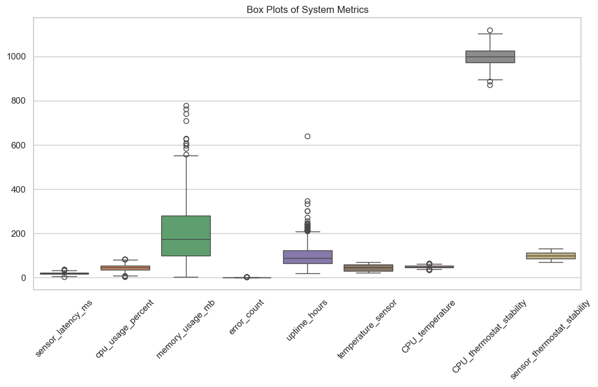

```python
plt.figure(figsize=(12, 6))
sns.boxplot(data=df[numerical_cols])
plt.title('Box Plots of System Metrics')
plt.xticks(rotation=45)
plt.show()
```

```python
# your answer here
Answer_Q21 = "..."
```

✅ Task for students: Look at the box plot above and answer:

- Is there anything else wrong with the plot and what can you do to improve it?

```python
# your answer here
Answer_Q22 = "..."
```

[figure not shown]

```python
# Your code to improve the plot here
```

### Section 3: Measures of Center and Variability

✅ Task for students: print the descriptive statistics to summarize the central tendency, dispersion and shape of all columns in the data

```python
# your code here
```

[output not shown]

✅ Task for students: Using the plots and the descriptive statistics above try to solve the following questions. Please complement with further measures if needed.

1. Which metric shows the most variability? Justify using both range and standard deviation.
2. Compare sensor latency and uptime. Which one is more consistent across systems
3. Can we compare variability across metrics with different units (e.g., ms vs MB)?
4. For which variable would the median be a better measure of "typical" than the mean?

```python
Answer_Q31 = "..."
Answer_Q32 = "..."
Answer_Q33 = "..."
Answer_Q34 = "..."
```

✅ Task for students:

1. Identify one metric where mean > median > mode. What does this indicate about skewness?
2. Can you find a metric there is not big differences between mean ≈ median ≈ mode? What does thus tell us about the distribution shape?

```python
# Your code here
```

[output not shown]

```python
Answer_Q35 = " ... "
```

```python
Answer_Q36 = " ... "
```

### Section 4: Quantiles, percentiles, and Outliers

✅ Task for students:

- calculate quantiles [0.01, 0.25, 0.5, 0.75, 0.99] for uptime_hours and sensor_latency_ms

```python
# Your code here
```

[output not shown]

✅ Task for students:

- calculate IQR for sensor_latency_ms

```python
# Your code here
# For sensor_latency_ms
```

[output not shown]

✅ Task for students:

- calculate IQR for uptime_hours

```python
# Your code here
# For uptime_hours
```

[output not shown]

The IQR outlier rule:

```
- Lower bound = Q1 − 1.5 × IQR

- Upper bound = Q3 + 1.5 × IQR
```

```python
# Your code here
```

[output not shown]

```python
# Your code here
```

[output not shown]

✅ Task for students: Why might some outliers be legitimate and not errors?

Values outside this range can be flagged as potential outliers, under some assumptions — such as the data being approximately symmetric and without heavy tails. In highly skewed or long-tailed distributions, this rule may flag many legitimate values as "outliers.

```python
Answer_Q41 = "..."
```

✅ Task for students:

- How can you use the percentiles/ IQR to conclude about the shape of the distribution of the values of uptime_hours?
- Check box plot / histograms do they confirm the distribution shape that you can conclude using percentiles?

### Section 5: compare variables

✅ Task for students: Which thermostat is more stable and consistent, print the mean values and standard deviations and explain why it can be misleading to use only these measures to compare

```python
# Variables to compare
var1 = "CPU_thermostat_stability"
var2 = "sensor_thermostat_stability"

# Your code here
```

```python
# Your code here
Answer_Q51 = "..."
```

### Section6: Scatter Plot Analysis

✅ Task for students:

1. can you identify any clusters or linear relationships between the variables: sensor_latency_ms and cpu_usage_percent. Which plot can we use to plot this?
2. Which mode is associated with higher CPU load?

```python
Answer_Q61 = "..."
```

[figure not shown]

```python
# Your code here
```

```python
Answer_Q62 = "..."
```

### Section7: Correlation Matrix

✅ Task for students:

- Code to identify the strongest positive and negative relationships between the variables

[figure not shown]

```python
# Your code here
```